# Precio de la vivienda en Boston

09/10/2024

## Introducción

En esta presentación se analizará el precio de la vivienda en la región de Boston utilizando modelos de regresión lineal múltiple.

Se evaluará el modelo en términos de ajuste, diagnóstico de residuos, y se realizarán pruebas de hipótesis para evaluar la significancia de los coeficientes.

## Estructura de variables

|  | Variable | Tipo de Dato | Primeros Valores | Valores Nulos |
| --- | --- | --- | --- | --- |
| CRIM | CRIM | numeric | 0.00632, 0.02731, 0.02729 | 0 |
| ZN | ZN | character | 18, 0, 0 | 0 |
| INDUS | INDUS | numeric | 2.31, 7.07, 7.07 | 0 |
| CHAS | CHAS | character | 0, 0, 0 | 0 |
| NOX | NOX | numeric | 0.538, 0.469, 0.469 | 0 |
| RM | RM | numeric | 6.575, 6.421, 7.185 | 0 |
| AGE | AGE | numeric | 65.2, 78.9, 61.1 | 0 |
| DIS | DIS | numeric | 4.09, 4.9671, 4.9671 | 0 |
| RAD | RAD | numeric | 1, 2, 2 | 0 |
| TAX | TAX | numeric | 296, 242, 242 | 0 |
| PTRATIO | PTRATIO | numeric | 15.3, 17.8, 17.8 | 0 |
| LSTAT | LSTAT | numeric | 4.98, 9.14, 4.03 | 0 |
| MEDV | MEDV | numeric | 24, 21.6, 34.7 | 0 |
| CAT. MEDV | CAT. MEDV | numeric | 0, 0, 1 | 0 |

## Análisis de Regresión Lineal Múltiple

El modelo de regresión lineal múltiple se definió con la variable dependiente `MEDV` (valor medio de las casas) y las siguientes variables independientes:

- `RM`: Número promedio de habitaciones por vivienda.
- `LSTAT`: Porcentaje de población de estatus socioeconómico más bajo.
- `CRIM`: Tasa de criminalidad per cápita por municipio.

## modelo

Resumen del Modelo de Regresión Lineal Múltiple

|  | Variable | Estimación | Error Estándar | Valor t | Valor Pr(>\|t\|) |
| --- | --- | --- | --- | --- | --- |
| (Intercept) | (Intercept) | -2.5623 | 3.1660 | -0.8093 | 0.4187 |
| RM | RM | 5.2170 | 0.4420 | 11.8021 | 0.0000 |
| LSTAT | LSTAT | -0.5785 | 0.0477 | -12.1354 | 0.0000 |
| CRIM | CRIM | -0.1029 | 0.0320 | -3.2147 | 0.0014 |

## Gráfico de Diagnóstico del Modelo de Regresión

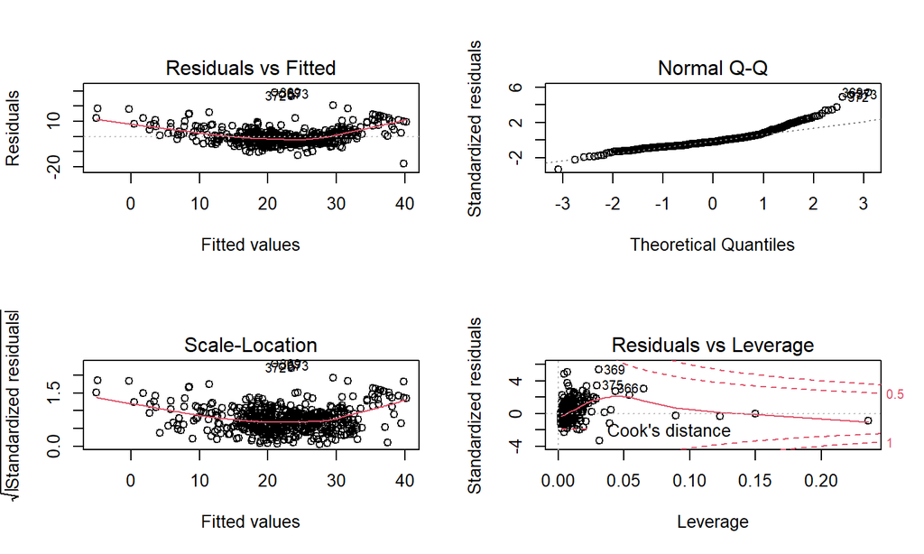

## Gráfico de Residuos vs. Valores Ajustados.

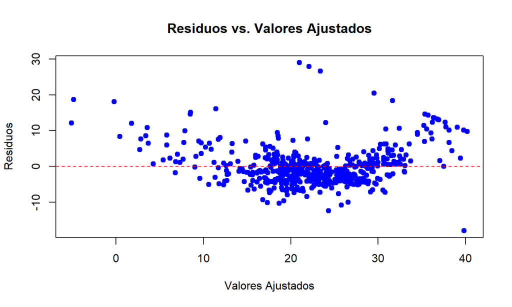

## Análisis de Varianza (ANOVA)

Análisis de Varianza (ANOVA) del Modelo de Regresión Lineal Múltiple

|  | Df | Sum Sq | Mean Sq | F value | Pr(>F) |
| --- | --- | --- | --- | --- | --- |
| RM | 1 | 20654.4162 | 20654.41622 | 685.39089 | 0.00000 |
| LSTAT | 1 | 6622.5700 | 6622.56999 | 219.76168 | 0.00000 |
| CRIM | 1 | 311.4208 | 311.42082 | 10.33411 | 0.00139 |
| Residuals | 502 | 15127.8884 | 30.13524 | NA | NA |

## Prueba de Heterocedasticidad de Breusch-Pagan

```
##
##  studentized Breusch-Pagan test
##
## data:  modelo_multiple
## BP = 7.4741, df = 3, p-value = 0.05823
```

## Prueba de Autocorrelación (Durbin-Watson)

```
##
##  Durbin-Watson test
##
## data:  modelo_multiple
## DW = 0.82183, p-value < 2.2e-16
## alternative hypothesis: true autocorrelation is greater than 0
```

## Comparación de viviendas con valor medio superior e inferior a 30 mil dólares

Se requiere comparar las viviendas con valor medio superior a 30 mil dólares y las que tienen un valor medio inferior a ese monto, utilizando pruebas t para comparar las diferencias entre los grupos en relación con algunas variables específicas

```
##
##  Welch Two Sample t-test
##
## data:  CRIM by factor(MEDV >= 30)
## t = 7.201, df = 501.92, p-value = 2.199e-12
## alternative hypothesis: true difference in means between group FALSE and group TRUE is not equal to 0
## 95 percent confidence interval:
##  2.552343 4.467669
## sample estimates:
## mean in group FALSE  mean in group TRUE
##           4.1962123           0.6862062
```

```
##
##  Welch Two Sample t-test
##
## data:  RM by factor(MEDV >= 30)
## t = -16.56, df = 106.86, p-value < 2.2e-16
## alternative hypothesis: true difference in means between group FALSE and group TRUE is not equal to 0
## 95 percent confidence interval:
##  -1.354526 -1.064896
## sample estimates:
## mean in group FALSE  mean in group TRUE
##            6.083813            7.293524
```

```
##
##  Welch Two Sample t-test
##
## data:  DIS by factor(MEDV >= 30)
## t = -2.5601, df = 113.35, p-value = 0.01178
## alternative hypothesis: true difference in means between group FALSE and group TRUE is not equal to 0
## 95 percent confidence interval:
##  -1.1922640 -0.1520052
## sample estimates:
## mean in group FALSE  mean in group TRUE
##            3.683463            4.355598
```

```
##
##  Welch Two Sample t-test
##
## data:  as.numeric(RAD) by factor(MEDV >= 30)
## t = 6.5817, df = 209.31, p-value = 3.673e-10
## alternative hypothesis: true difference in means between group FALSE and group TRUE is not equal to 0
## 95 percent confidence interval:
##  3.241152 6.012967
## sample estimates:
## mean in group FALSE  mean in group TRUE
##           10.317536            5.690476
```

## Pruebas de hipótesis para proporciones

```
##
##  2-sample test for equality of proportions with continuity correction
##
## data:  c(sum(boston_data$MEDV >= 30 & boston_data$PTRATIO < 20), sum(boston_data$MEDV < 30 & boston_data$PTRATIO < 20)) out of c(sum(boston_data$MEDV >= 30), sum(boston_data$MEDV < 30))
## X-squared = 46.298, df = 1, p-value = 1.016e-11
## alternative hypothesis: two.sided
## 95 percent confidence interval:
##  0.3283365 0.4815258
## sample estimates:
##    prop 1    prop 2
## 0.9404762 0.5355450
```

## Matriz de correlación y selección de predictores

```
##         RM         ZN        DIS        AGE        RAD       CRIM        NOX
##  0.6953599  0.3604453  0.2499287 -0.3769546 -0.3816262 -0.3883046 -0.4273208
##        TAX      INDUS    PTRATIO      LSTAT
## -0.4685359 -0.4837252 -0.5077867 -0.7376627
```

## gráfico para visualizar las correlaciones

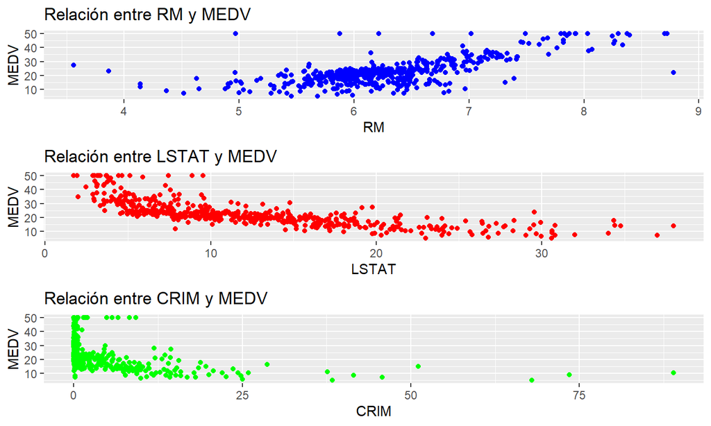

## Comparación de Viviendas según Valor Medio

Comparación de Variables según el Valor Medio de las Viviendas

[output not shown]

## Análisis de Proporciones

Comparación de Proporciones para PTRATIO < 20

| Grupo | Proporción con PTRATIO < 20 | p-valor |
| --- | --- | --- |
| Viviendas >= 30 mil | 0.9404762 | 0 |
| Viviendas < 30 mil | 0.5355450 | 0 |

## Modelo de regresión

Resumen del Modelo Completo de Regresión Lineal Múltiple

|  | Variable | Estimación | Error Estándar | Valor t | Valor Pr(>\|t\|) |
| --- | --- | --- | --- | --- | --- |
| (Intercept) | (Intercept) | 42.9545 | 3.8169 | 11.2538 | 0.0000 |
| CRIM | CRIM | -0.1297 | 0.0255 | -5.0819 | 0.0000 |
| ZN | ZN | -0.0051 | 0.0111 | -0.4605 | 0.6454 |
| INDUS | INDUS | 0.1143 | 0.0484 | 2.3632 | 0.0185 |
| CHAS | CHAS | 2.3598 | 0.6731 | 3.5057 | 0.0005 |
| NOX | NOX | -15.3624 | 2.9834 | -5.1493 | 0.0000 |
| RM | RM | 1.0583 | 0.3548 | 2.9831 | 0.0030 |
| AGE | AGE | -0.0062 | 0.0103 | -0.5971 | 0.5507 |
| DIS | DIS | -0.7335 | 0.1613 | -4.5470 | 0.0000 |
| RAD | RAD | 0.2052 | 0.0519 | 3.9522 | 0.0001 |
| TAX | TAX | -0.0094 | 0.0029 | -3.1822 | 0.0016 |
| PTRATIO | PTRATIO | -0.5580 | 0.1043 | -5.3496 | 0.0000 |
| LSTAT | LSTAT | -0.4784 | 0.0394 | -12.1499 | 0.0000 |
| `CAT. MEDV` | `CAT. MEDV` | 11.8140 | 0.6476 | 18.2429 | 0.0000 |

## Modelo con la vivienda

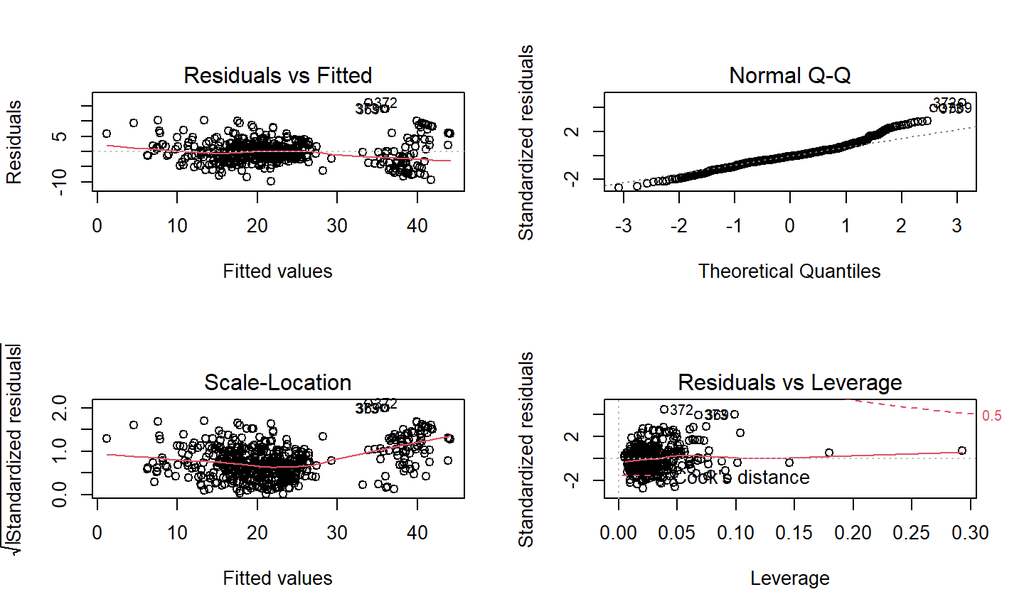

## Predicción de una Nueva Vivienda

Predicción del Valor Medio para una Nueva Vivienda

| Valor Estimado | Límite Inferior | Límite Superior |
| --- | --- | --- |
| 28.86 | 18.05 | 39.67 |

## Conclusiones

- Se detectaron algunos puntos influyentes y patrones en los residuos que sugieren la necesidad de ajustar el modelo o explorar transformaciones de variables.
- La tasa de criminalidad (CRIM) y el porcentaje de bajo estatus (LSTAT) tienen un impacto significativo en el valor de las viviendas.

## Referencias.

Shmueli, G., & Bruce, P. (2016). Data Mining for Business Analytics: Concepts, Techniques, and Applications in R. Wiley.

Harrison, D., & Rubinfeld, D. L. (1978). Hedonic prices and the demand for clean air. Journal of Environmental Economics and Management, 5(1), 81-102.